# ggplot2: The basics

## coord_trans

apply a transform to your coordinates, simpler than applying it to the data…

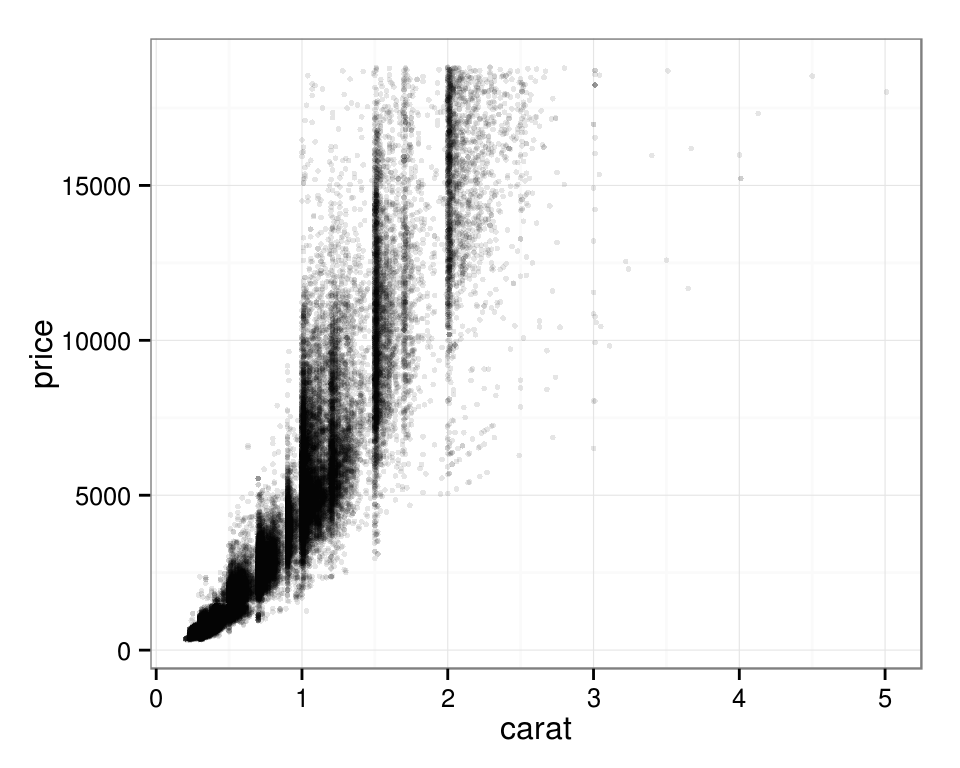

```r
ct.plot = ggplot(diamonds, aes(carat,price))+geom_point(alpha=I(0.1),size=1)+
  theme_bw()
ct.plot
```

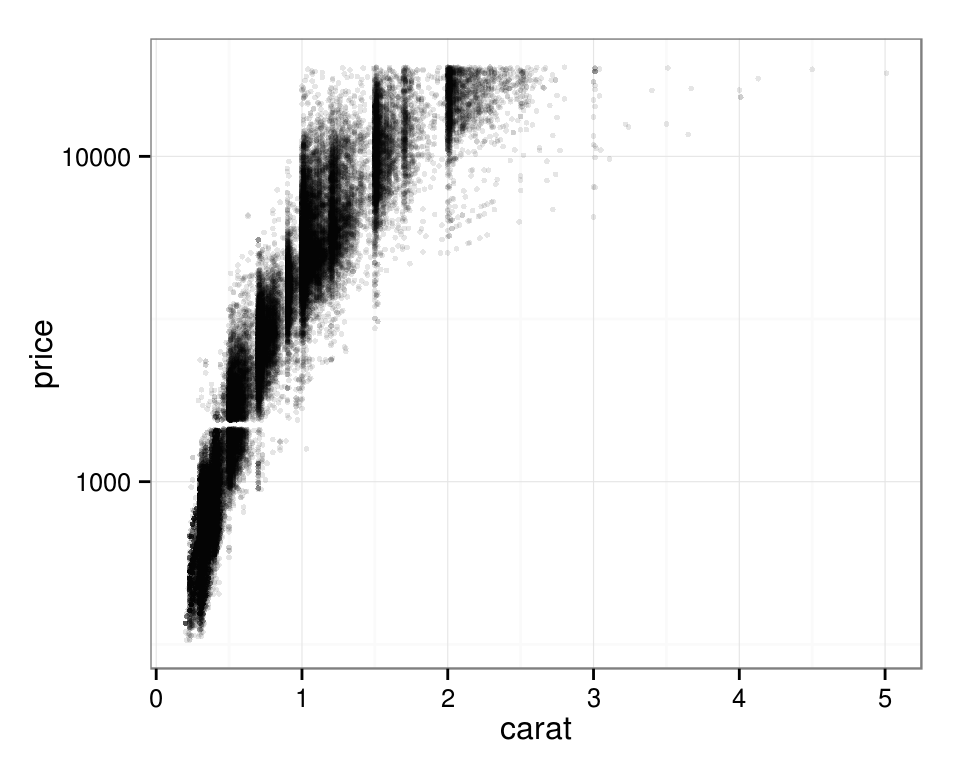

```r
ct.plot + scale_y_log10()
```

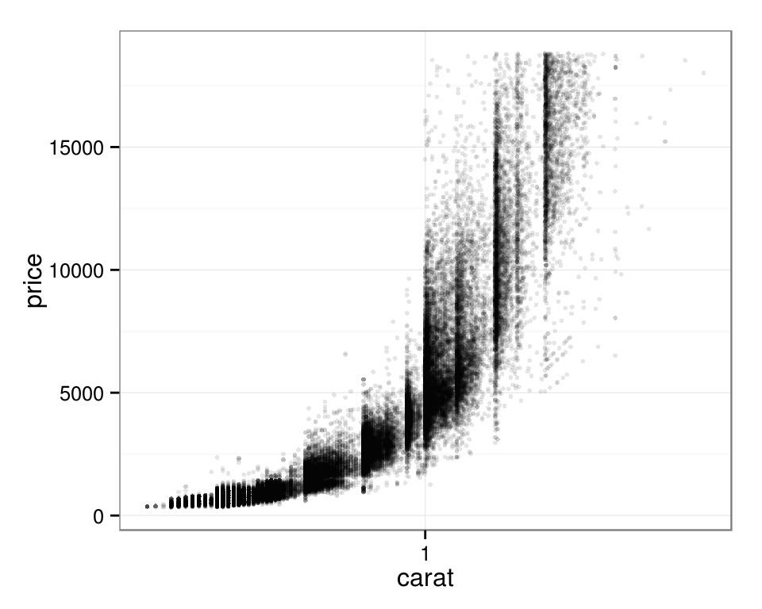

```r
ct.plot + scale_x_log10()
```

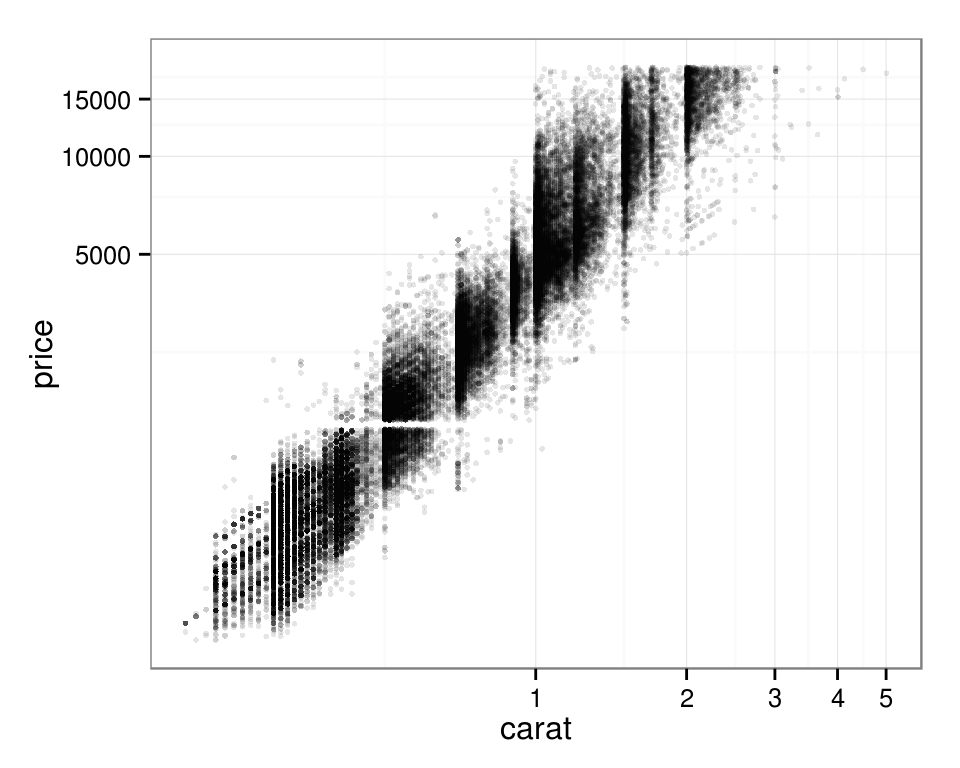

```r
ct.plot + coord_trans(x="log10",y="log10")
```

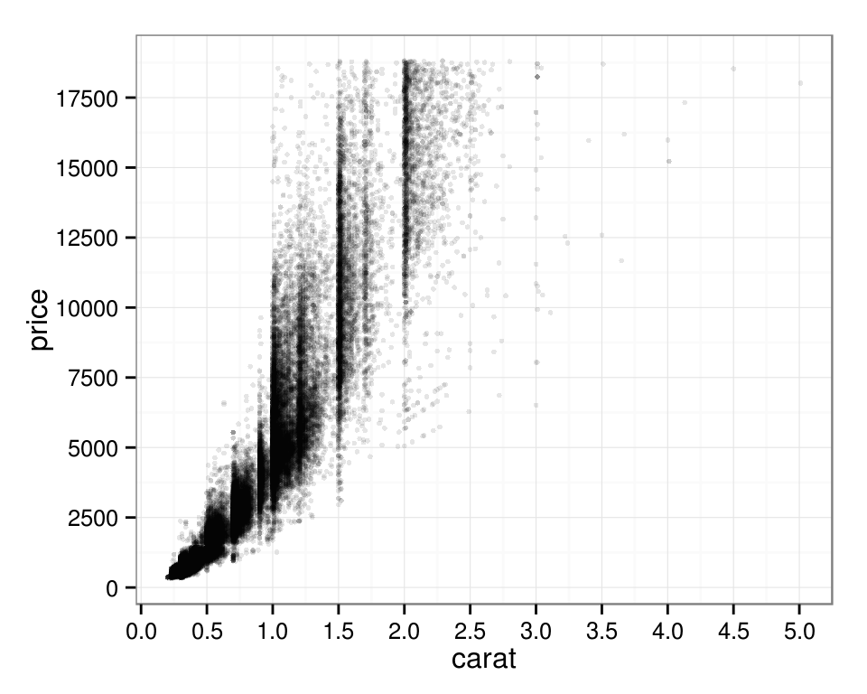

```r
#'# change the axis ticks w/ labels
ct.plot + scale_y_continuous(breaks= seq(0,20000,by=2500))+
  scale_x_continuous(breaks= seq(0,5,by=0.5))
```

## Color/Fill

note: different scales are used for discrete and continuous data scale_color_manual for discrete data

```r
scm.plot = ggplot(iris,aes(x=Sepal.Length,y=Sepal.Width,color=factor(Species))) + geom_point(size=3)+
  theme_bw()
```

#### automatic assignment

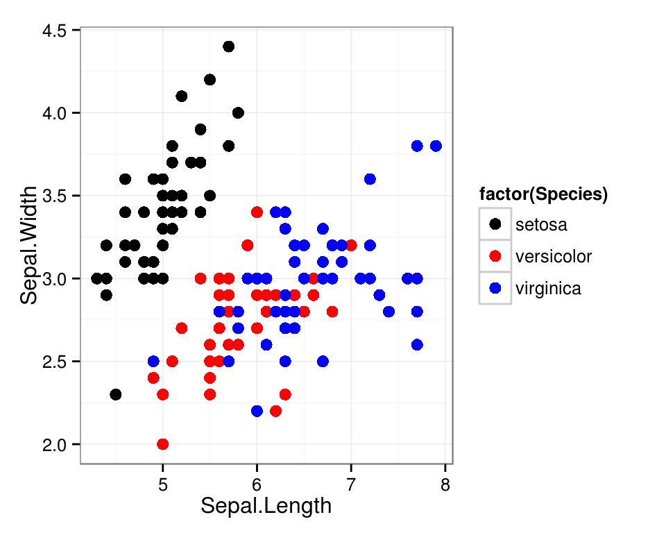

```r
scm.plot + scale_color_manual(values=c("black","red","blue"))
```

#### specify colors and assignment to factor values

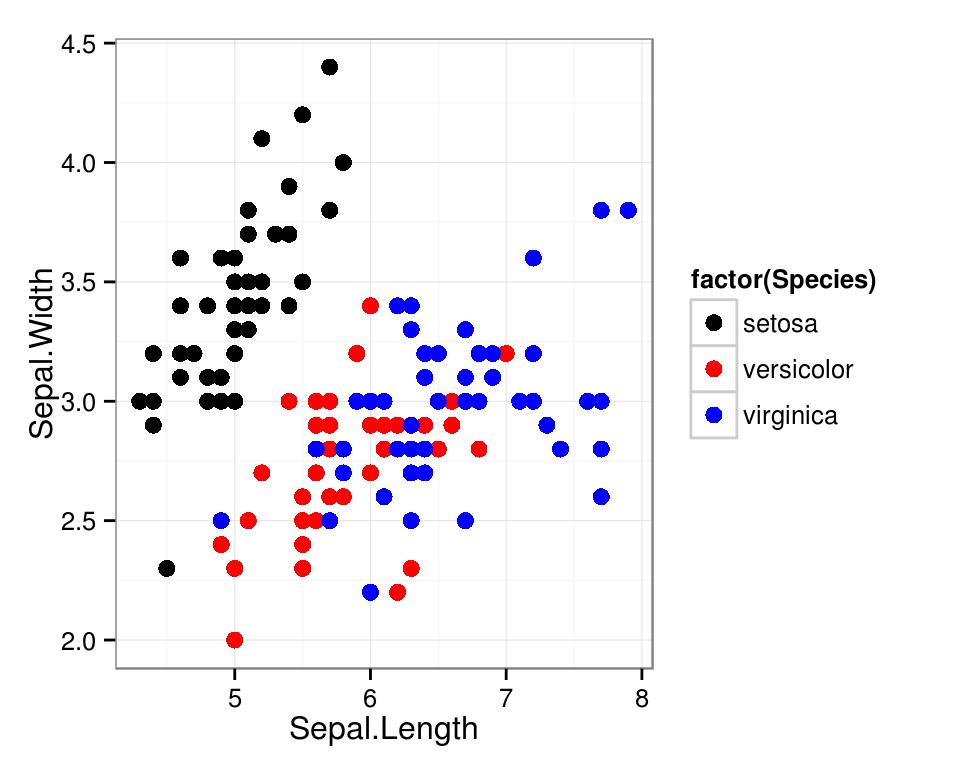

```r
scm.plot + scale_color_manual(values=c("setosa"= "black","versicolor"= "red","virginica"= "blue"))
```

#### scale_colour_gradient for continuous data

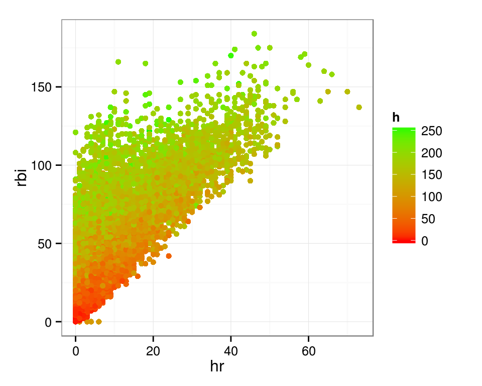

```r
ggplot(baseball,aes(x=hr,y=rbi,color=h))+ geom_point()+
  theme_bw() +
  scale_colour_gradient(low="red",high="green")
```

#### scale_colour_gradientn provides smoothing over multiple color values…

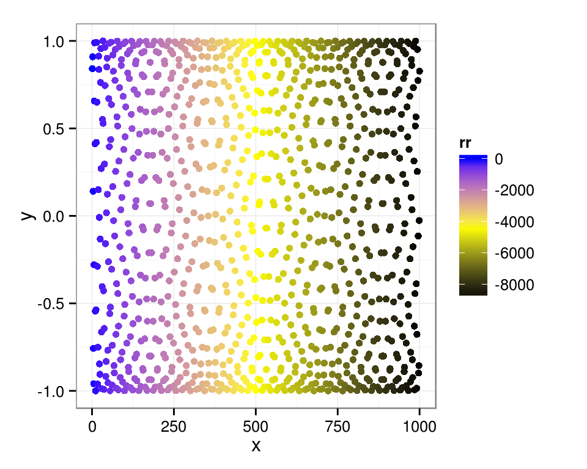

```r
sin.df <-data.frame(x=1:1000,y=sin(1:1000),rr=1:1000 - (2*pi)*(1:1000 %/% 2*pi))
ggplot(sin.df,aes(x,y,color=rr))+geom_point(size=2)+theme_bw()+
  scale_colour_gradientn(colours=c("black","yellow","blue"))
```

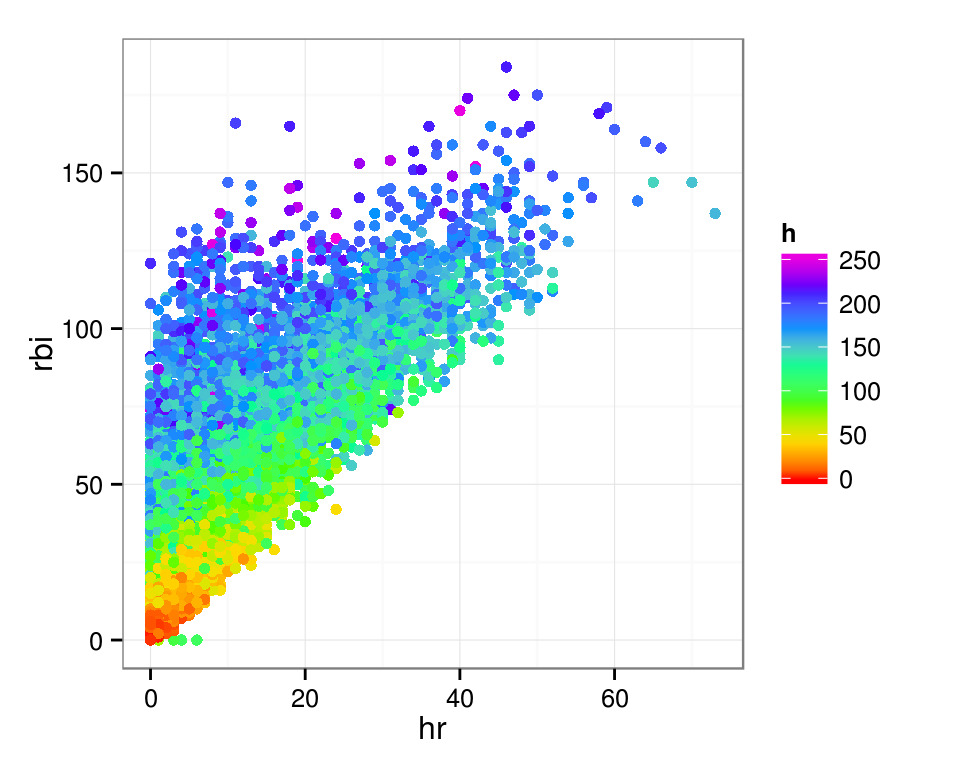

```r
scgn.plot = ggplot(baseball,aes(x=hr,y=rbi,color=h))+ geom_point()+ theme_bw()
scgn.plot + scale_color_gradientn(colours=rainbow(7))
```

#### you can cycle through the colors for better resolution

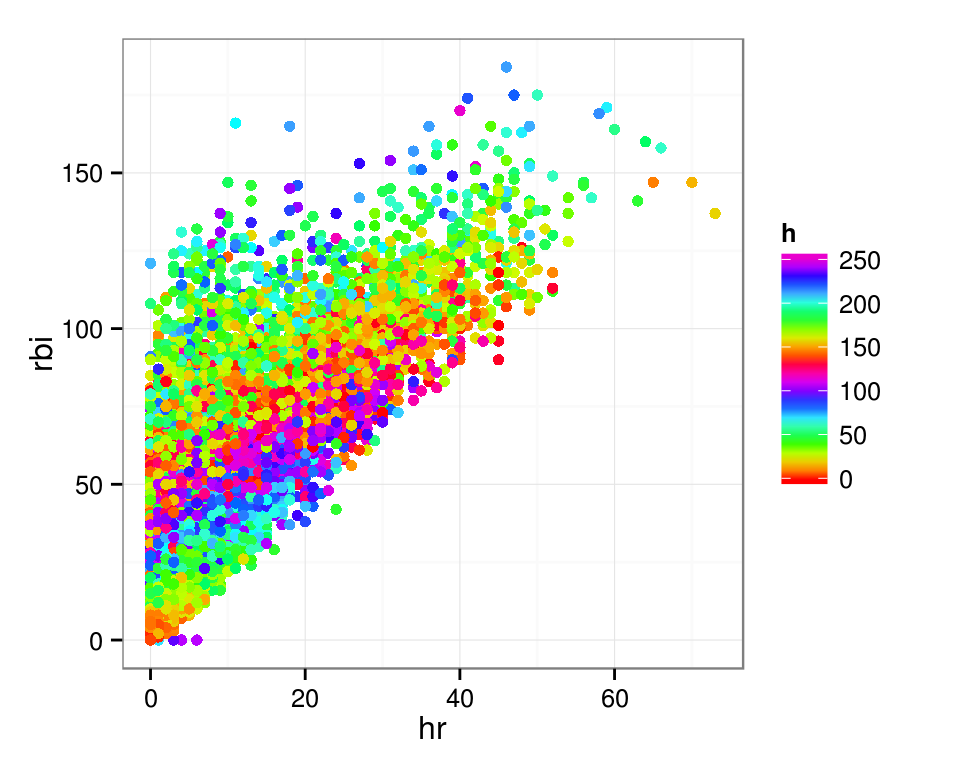

```r
scgn.plot + scale_color_gradientn(colours=rep(rainbow(10),2))
```

### scale_colour_brewer, offers a set of nice palettes for discrete coloring:

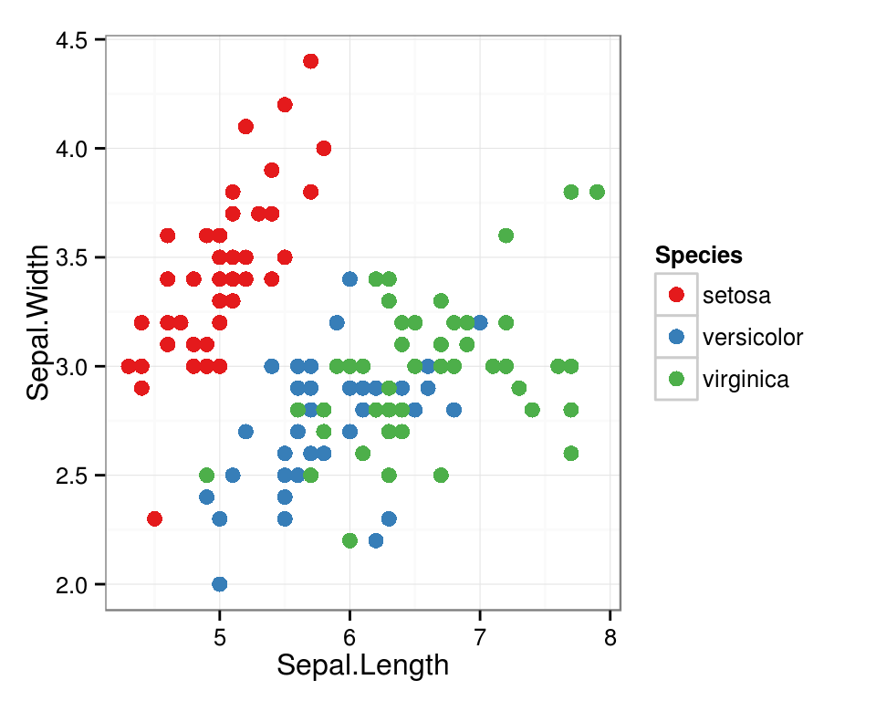

```r
ggplot(iris,aes(x=Sepal.Length,y=Sepal.Width,color=Species)) +
  geom_point(size=3) +
  scale_colour_brewer(palette="Set1")+theme_bw()
```

### scale_fill_*

works the same as the scale_colour_*, and is used when the geom is “filled” instead of “colored” (note this change from factor to integer is improper)

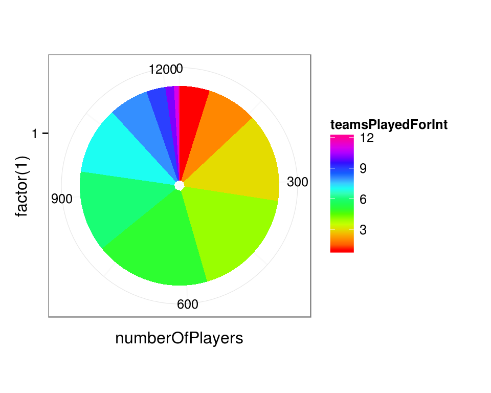

```r
teamsPerPlayer.df$teamsPlayedForInt = 1:12

ggplot(teamsPerPlayer.df,aes(x=factor(1),y=numberOfPlayers,fill=teamsPlayedForInt)) +
  geom_bar(stat="identity") +
  theme_bw() +
  coord_polar(theta="y")+
  scale_fill_gradientn(colours=rainbow(10))
```

#### we can try again using discrete values to get proper labels…

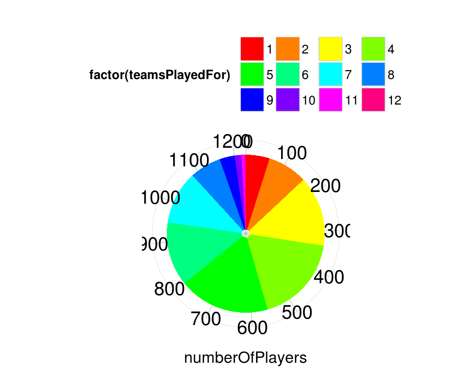

```r
ggplot(teamsPerPlayer.df,aes(x=factor(1),y=numberOfPlayers,fill=factor(teamsPlayedFor))) +
  geom_bar(stat="identity") +
  theme_bw() +
  coord_polar(theta="y")+
  scale_fill_manual(values=rainbow(12),guide= guide_legend(ncol = 4,byrow=TRUE))+
  theme(legend.position = "top",
        panel.grid.minor.y = element_line(colour = "grey"),
        panel.grid.major.y = element_line(colour = "grey"),
        axis.text.x = element_text(size=rel(1.5)),
        axis.text.y = element_blank(),
        panel.border = element_blank(),
        axis.ticks.y = element_blank()) +
  scale_y_discrete(limits= seq(0,1228,by=100))+
  xlab("")
```

# Advanced Examples

## ex. 1

objective: look at the variance and mean of samples of discrete data approach: create a function that initiates the dataset, then returns a function whose arguments set the plot window

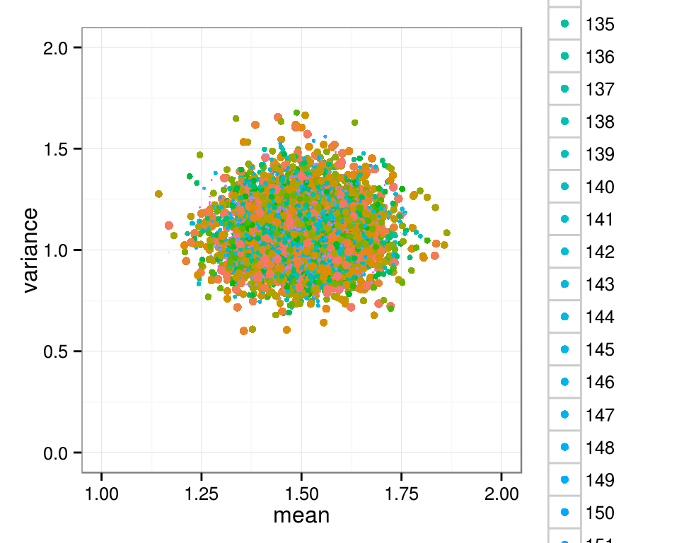

```r
makePlotFunction <-function(size,fun,mean,range,rangeLower=2){
  df<-as.data.frame(t(as.matrix(
    sapply(floor(runif(size)*(range))+ rangeLower,
           function(x){vec<-sapply(fun(x,mean),floor);
                       c(mean(vec),var(vec),length(vec))}))))#end of data.frame
  colnames(df)<-c("mean","variance","n");
  function(pMin,pMax,xVec,yVec){
    df$pSize = as.numeric(df$n)
    ggplot(df,aes(x=mean,y=variance,color=factor(n),size=pSize))+
      geom_point()+
      scale_size(range = c(pMin,pMax))+
      theme_bw()+
      xlim(xVec)+
      ylim(yVec)}}

# set the function
f1= makePlotFunction(size=10000,fun=rnorm,mean=2,range=80,rangeLower=100)
f1(xVec=c(1,2),yVec=c(0,2),pMin=2.2,pMax=0.2)
```

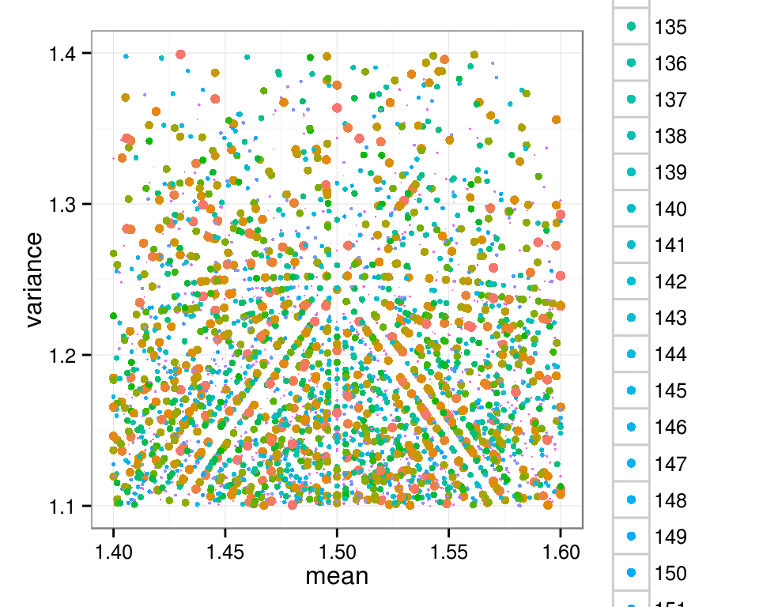

```r
f1(xVec=c(1.4,1.6),yVec=c(1.1,1.4),pMin=2.2,pMax=0.2)
```

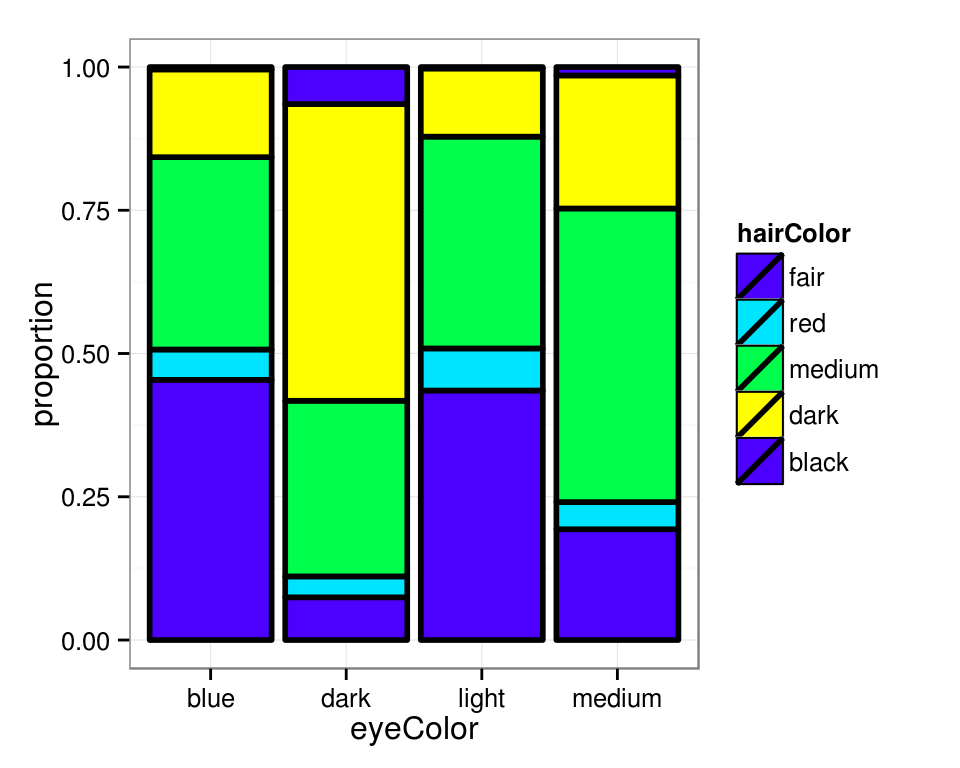

```r
# Mosiac Plot
library(MASS)
data(caith)

# melt function :: wide data.frame -> long data.frame
caith.melt= melt(
  cbind(as.data.frame(caith),
        row=rownames(caith)),
  id.var=c("row"))

#' rename the columns
colnames(caith.melt) = c("eyeColor","hairColor","proportion")

ggplot(caith.melt ,aes(x=eyeColor,y=proportion,fill=hairColor,color=hairColor)) +
  geom_bar(position="fill",stat="identity",size=1) +
  scale_fill_manual(values=c(topo.colors(4),topo.colors(1))) +
  theme_bw() +
  scale_color_manual(values=rep("black",6))
```

## Mandelbrot set

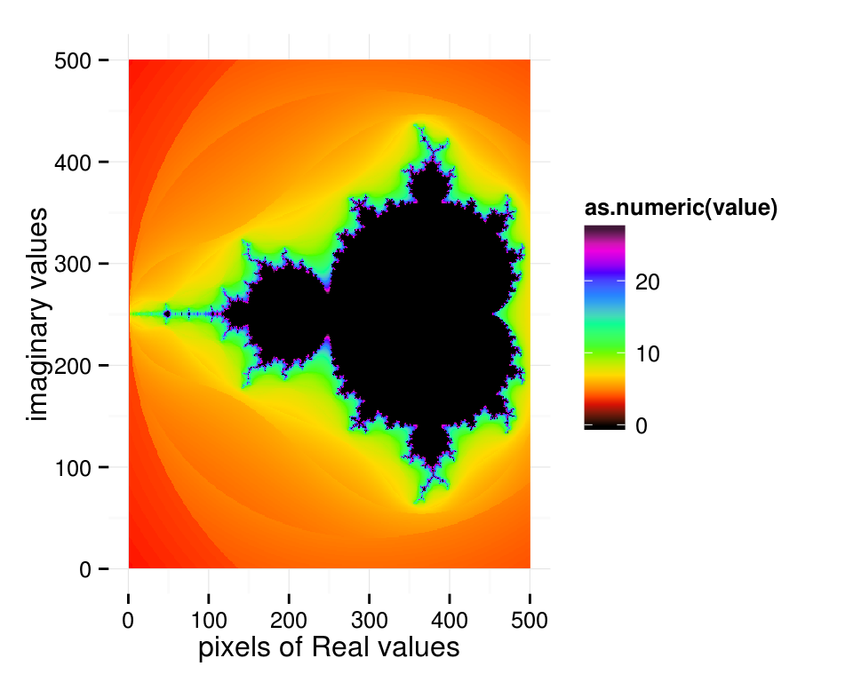

```r
normIter3 = function(n,z,P=2,N=200){n - log( (log(abs(z),base=N)),base=P) }
iterate.until.escape <- function(z, c, trans, cond, max=50, response=dwell) {
  #we iterate all active points in the same array operation,
  #and keeping track of which points are still iterating.
  active <- seq_along(z)
  dwell <- z
  dwell[] <- 0
  for (i in 1:max) {
    z[active] <- trans(z[active], c[active]);
    survived <- cond(z[active])
    dwell[active[!survived]] <- normIter3(i, z[active[!survived]])
    #dwell[active[!survived]] <- i
    active <- active[survived]
    if (length(active) == 0) break
  }
  eval(substitute(response))
}


getArrayZoom <- function(re.vec=c(-2,1),im.vec=c(-1.5,1.5),max=25,len=500){
  re = seq(re.vec[1], re.vec[2], len=len)
  im = seq(im.vec[1], im.vec[2], len=len)
  c <- outer(re, im, function(x,y) complex(real=x, imaginary=y))
  x <- iterate.until.escape(array(0, dim(c)), c,
                            function(z,c)z^2+c,
                            function(z)abs(z) <= 2,
                            max=max) # was 100
  melt(x)
}

xRel = c(-2,0.5)
yImg = c(-1.5,1.5)

ggplot(getArrayZoom(re.vec=xRel,
                    im.vec=yImg),
       aes(Var1,Var2,fill=as.numeric(value))) +
  geom_raster() +
  scale_fill_gradientn(colours=c("black",(rainbow(7)),na.value="black")) +
  theme_minimal()+
  xlab("pixels of Real values")+
  ylab("imaginary values")
```

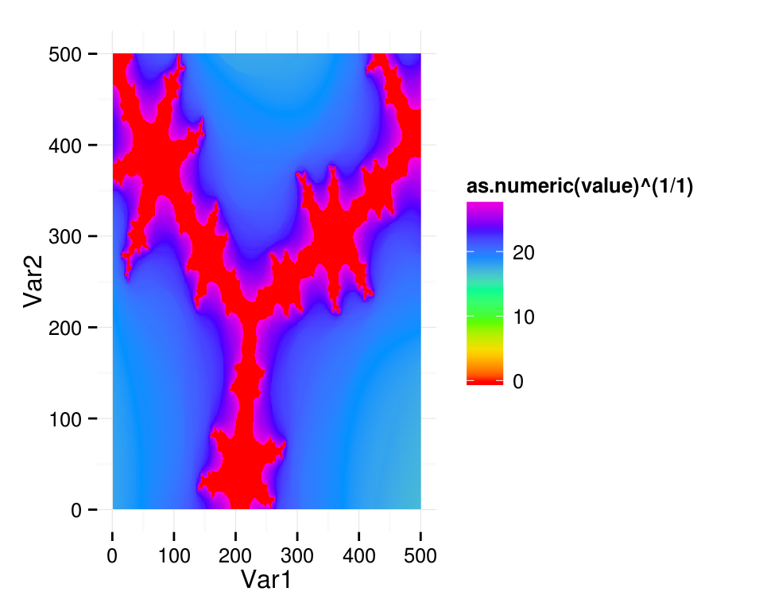

```r
ggplot(getArrayZoom(re.vec=c(-0.11,-.09),im.vec=c(0.95,0.965)), aes(Var1,Var2,fill=as.numeric(value)^(1/1))) +
  geom_raster() +
  scale_fill_gradientn(colours=rainbow(7),na.value="black") +
  theme_minimal()
```

## Path

instead of a line, we can follow each subsequent point to the next…

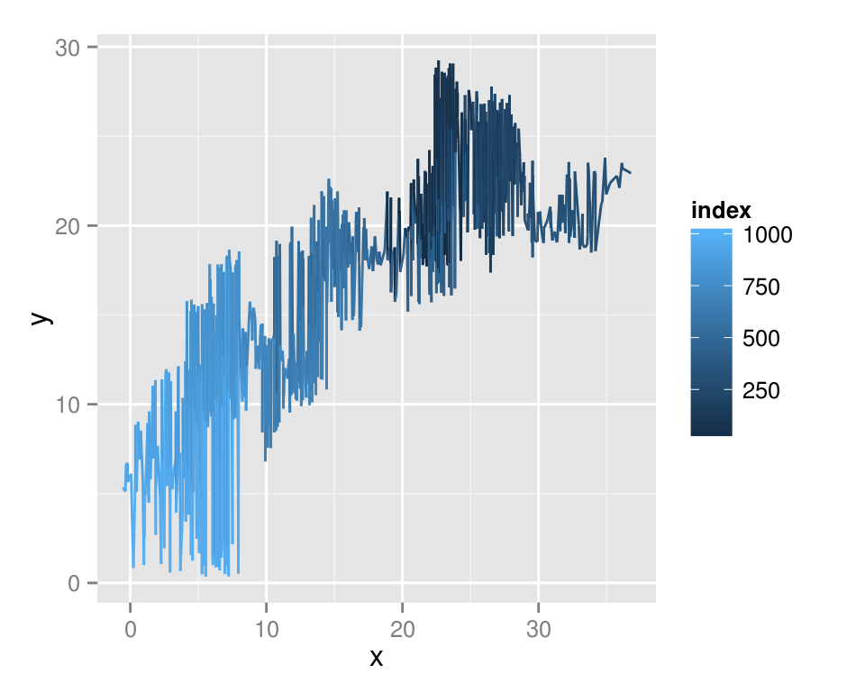

```r
# create a random walk:
steps = 500
#' set our reduce function, so we don't have to use loops...
reduceFn = function(x,y)c(x[1]+runif(1)*2 - 1,x)
#' create a function that returns a data.frame with a random walk of "steps" steps
randomWalk  = function(steps)data.frame(x= Reduce(f=reduceFn,1:steps,init=c(1)),
                                        y=  Reduce(f=reduceFn,1:steps,init=c(1)),
                                        index=1:(steps + 1))

#' if you use a line plot, notice that the x values are ordered...
ggplot(randomWalk(1000),aes(x,y,color=index))+geom_line()
```

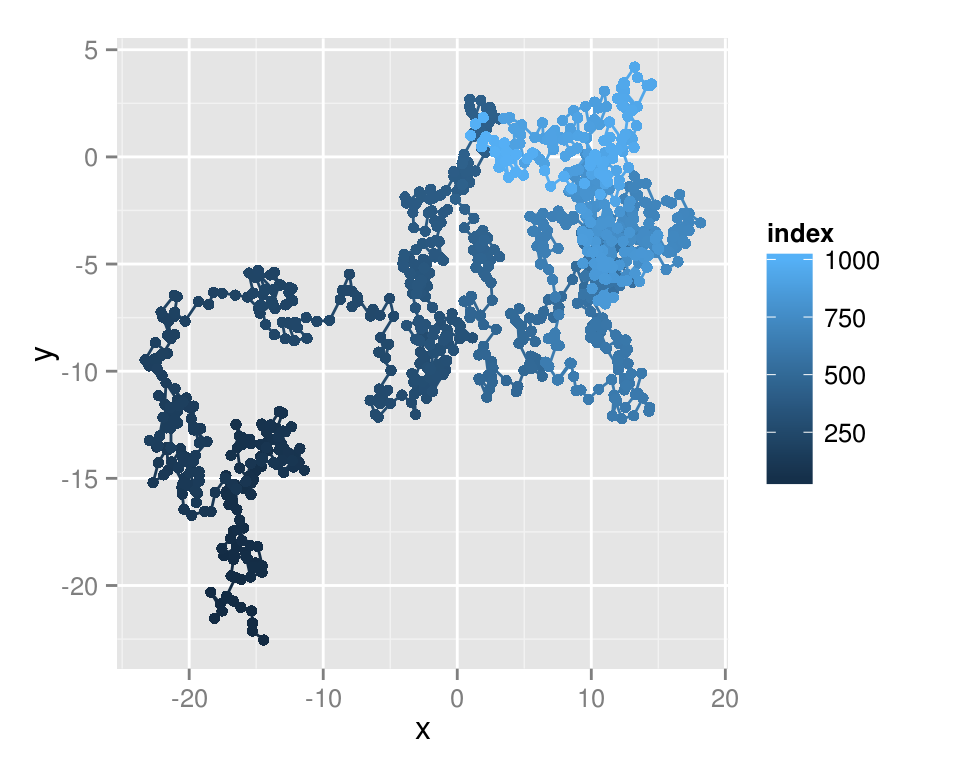

```r
ggplot(randomWalk(1000),aes(x,y,color=index))+geom_path() + geom_point()
```